# Project - Statiscal Methods for Decision Making

## 2.4. Note that there are three numerical (continuous) variables in the data set, Salary, Spending and Text Messages. For each of them comment whether they follow a normal distribution.

Write a note summarizing your conclusions. [Recall that symmetric histogram does not necessarily mean that the underlying distribution is symmetric]

```python
#Checking summary of data
df2.describe()
```

|  | ID | Age | GPA | Salary | Social Networking | Satisfaction | Spending | Text Messages |
| --- | --- | --- | --- | --- | --- | --- | --- | --- |
| count | 62.000000 | 62.000000 | 62.000000 | 62.000000 | 62.000000 | 62.000000 | 62.000000 | 62.000000 |
| mean | 31.500000 | 21.129032 | 3.129032 | 48.548387 | 1.516129 | 3.741935 | 482.016129 | 246.209677 |
| std | 18.041619 | 1.431311 | 0.377388 | 12.080912 | 0.844305 | 1.213793 | 221.953805 | 214.465950 |
| min | 1.000000 | 18.000000 | 2.300000 | 25.000000 | 0.000000 | 1.000000 | 100.000000 | 0.000000 |
| 25% | 16.250000 | 20.000000 | 2.900000 | 40.000000 | 1.000000 | 3.000000 | 312.500000 | 100.000000 |
| 50% | 31.500000 | 21.000000 | 3.150000 | 50.000000 | 1.000000 | 4.000000 | 500.000000 | 200.000000 |
| 75% | 46.750000 | 22.000000 | 3.400000 | 55.000000 | 2.000000 | 4.000000 | 600.000000 | 300.000000 |
| max | 62.000000 | 26.000000 | 3.900000 | 80.000000 | 4.000000 | 6.000000 | 1400.000000 | 900.000000 |

To check whether a variable follows normal distribution, we can use various methods -

1. Comparing the value of mean media and mode along with looking at the spread of the distribution. For normal disitrbution, we would have a symmetric bell shaped curve, and the value of mean=median=mode
2. Checking the skewness of the distribution of the variable. For a normal distribution the skewness would be 0
3. Using the Shapiro test to test for normality

#### 1. Checking the distribution of data along with the value of Mean, Median and Mode.

```
Mean: 48.55 Median: 50.0 Mode: 0    40.0
dtype: float64
```

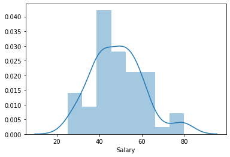

```python
# For a normal distribution mean = median = mode
sns.distplot(df2['Salary'])
mean_salary = round((df2['Salary'].mean()),2)
median_salary=df2['Salary'].median()
mode_salary=df2['Salary'].mode()
print("Mean:",mean_salary,"Median:",median_salary,"Mode:",mode_salary)
```

```
Mean: 482.02 Median: 500.0 Mode: 0    500
dtype: int64
```

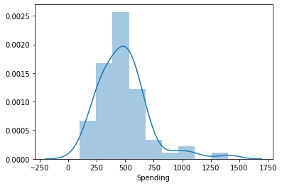

```python
sns.distplot(df2['Spending'])
mean_spend = round((df2['Spending'].mean()),2)
median_spend=df2['Spending'].median()
mode_spend=df2['Spending'].mode()
print('Mean:',mean_spend,'Median:',median_spend,"Mode:",mode_spend)
```

```
Mean: 246.21 Median: 200.0 Mode: 0    300
dtype: int64
```

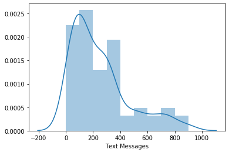

```python
sns.distplot(df2['Text Messages'])
mean_text = round((df2['Text Messages'].mean()),2)
median_text=round((df2['Text Messages'].median()),0)
mode_text=df2['Text Messages'].mode()
print('Mean:',mean_text,'Median:',median_text, 'Mode:',mode_text)
```

We can see from the distribution plot that distribution for salary is closest to the normal distribution, however it is not normally distributed. Further we can also observe from the mean median and mode values, that the difference between these is the least for Salary. For the other cases the difference is more and hence the variables do not follow the normal distribution

#### 2. Skewness

```python
pd.DataFrame({'Skewness' : [stats.skew(df2['Text Messages']),stats.skew(df2.Spending),stats.skew(df2.Salary)]},
                        index=['Text Messages','Spending','Salary'])
```

|  | Skewness |
| --- | --- |
| Text Messages | 1.264245 |
| Spending | 1.547285 |
| Salary | 0.521677 |

Basis the values of Skewness we can infer the following

1. Text Messages - The value of skewness is 1.2 which means the distributions is right skewed and hence does not follow normal distribution
2. Spending - The value of skewness is 1.5 which means the distribution is rights skewed and hence does not follow normal distribution
3. Salary - The value of skewness is 0.5 which means the distrbution is slightly skewed to the right. This variable is the closest to the normal distribution. However, as there is skewness it also does not follow normal disitrbuiton

#### 3. Shapiro's Test

Formulating the null and alternative hypothesis -

Ho: Variable follows normal distribution

Ha: Variable does not follow normal distribution

```python
# Calculating the Shapiro's statistic for Spending variable
stat_spend,p_spend=shapiro(df2['Spending'])
print('Statistic=%.3f, p=%.6f' % (stat_spend, p_spend))
```

```
Statistic=0.878, p=0.000017
```

With a confidence interval of 0.05, we can infer from the p-value that Spending variable does not follow normal distribution

```python
stat,p=shapiro(df2['Salary'])
print('Statistic=%.3f, p=%.6f' % (stat, p))
```

```
Statistic=0.957, p=0.028001
```

```python
stat,p=shapiro(df2['Text Messages'])
print('Statistic=%.3f, p=%.6f' % (stat, p))
```

```
Statistic=0.859, p=0.000004
```

With a confidence interval of 0.05, we can infer from the p-value that Text Messages variable does not follow normal distribution

Problem 3

An important quality characteristic used by the manufacturers of ABC asphalt shingles is the amount of moisture the shingles contain when they are packaged. Customers may feel that they have purchased a product lacking in quality if they find moisture and wet shingles inside the packaging. In some cases, excessive moisture can cause the granules attached to the shingles for texture and colouring purposes to fall off the shingles resulting in appearance problems. To monitor the amount of moisture present, the company conducts moisture tests. A shingle is weighed and then dried. The shingle is then reweighed, and based on the amount of moisture taken out of the product, the pounds of moisture per 100 square feet is calculated. The company would like to show that the mean moisture content is less than 0.35 pound per 100 square feet. The file (A & B shingles.csv) includes 36 measurements (in pounds per 100 square feet) for A shingles and 31 for B shingles.

```python
#loading the file
df3=pd.read_csv('A&B shingles.csv')
df3.head(5)
```

|  | A | B |
| --- | --- | --- |
| 0 | 0.44 | 0.14 |
| 1 | 0.61 | 0.15 |
| 2 | 0.47 | 0.31 |
| 3 | 0.30 | 0.16 |
| 4 | 0.15 | 0.37 |

```python
df3.info()
```

```
<class 'pandas.core.frame.DataFrame'>
RangeIndex: 36 entries, 0 to 35
Data columns (total 2 columns):
A    36 non-null float64
B    31 non-null float64
dtypes: float64(2)
memory usage: 704.0 bytes
```

```python
# Checking the summary of data
df3.describe()
```

|  | A | B |
| --- | --- | --- |
| count | 36.000000 | 31.000000 |
| mean | 0.316667 | 0.273548 |
| std | 0.135731 | 0.137296 |
| min | 0.130000 | 0.100000 |
| 25% | 0.207500 | 0.160000 |
| 50% | 0.290000 | 0.230000 |
| 75% | 0.392500 | 0.400000 |
| max | 0.720000 | 0.580000 |

```python
df3.isnull().sum() #Checking for missing values
```

```
A    0
B    5
dtype: int64
```

```python
df3.dropna(inplace=True) #Removing cells with null values
df3.info()
```

```
<class 'pandas.core.frame.DataFrame'>
Int64Index: 31 entries, 0 to 30
Data columns (total 2 columns):
A    31 non-null float64
B    31 non-null float64
dtypes: float64(2)
memory usage: 744.0 bytes
```

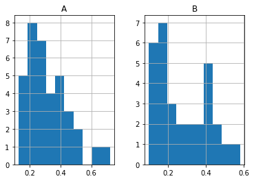

```python
df3.hist()
plt.show()
```

Both variables seem to be right skewed

## 3.1. For the A shingles, form the null and alternative hypothesis to test whether the population mean moisture content is less than 0.35 pound per 100 square feet.

Ho : 𝜇 ≥ 0.35 - Population mean moisture content of A shingles is greater than equal to 0.35 pound per 100 square feet

Ha : 𝜇 <0.35 - Population mean moisture content of A shignles is less than 0.35 pound per 100 square feet

## 3.2. For the A shingles, conduct the test of hypothesis and find the p-value. Interpret the p-value.

Is there evidence at the 0.05 level of significance that the population mean moisture content is less than 0.35 pound per 100 square feet?

```python
#Calculating the statistic and p-value for the aforementioned hypothesis:
t_statistic, p_value = ttest_1samp(df3['A'], 0.35)
print('T-Statistic:',t_statistic,'p-value:',p_value)
```

```
T-Statistic: -1.6005252585398313 p-value: 0.11996170801033942
```

## 3.3. For the B shingles, form the null and alternative hypothesis to test whether the population mean moisture content is less than 0.35 pound per 100 square feet.

Ho : 𝜇 ≥ 0.35 - Population mean moisture content of B shingles is greater than equal to 0.35 pound per 100 square feet

Ha : 𝜇 <0.35 - Population mean moisture content of B shingles is less than 0.35 pound per 100 square feet

## 3.4. For the B shingles, conduct the test of the hypothesis and find the p-value.

Interpret the p-value. Is there evidence at the 0.05 level of significance that the population mean moisture content is less than 0.35 pound per 100 square feet?

```python
t_statistic, p_value = ttest_1samp(df3['B'], 0.35)
print('T-Statistic:',t_statistic,'p-value:',p_value)
```

```
T-Statistic: -3.1003313069986995 p-value: 0.004180954800638363
```

In this case, the p value is 0.0041 which is lesser than 0.05, hence we reject the null hypothesis that the population mean moisture content is greater than equal to 0.35 pound per 100 square feet

## 3.5. Do you think that the population means for shingles A and B are equal?

Form the hypothesis and conduct the test of the hypothesis. What assumption do you need to check before the test for equality of means is performed?

Ho : 𝜇A = 𝜇B - Population mean moisture content of A shingles is equal to Population mean moisture content of B shingles

Ha : 𝜇A ≠ 𝜇B - Population mean moisture content of A shingles is not equal to Population mean moisture content of B shingles

```python
#We need to check the assumption that both population variances are equal before performing the test for equality of means
#We use the levene test to check the same
#Ho: Var(A)=Var(B)
#Ha: Var(A)≠Var(B)
stats.levene(df3['A'],df3['B'])
```

```
LeveneResult(statistic=nan, pvalue=nan)
```

Further, we calculate the t statistic and p-value to test our hypothesis

```python
t_statistic, p_value = ttest_ind(df3['A'], df3['B'])
print('T-Statistic:',t_statistic,'p-value:',p_value)
```

```
T-Statistic: 0.985249977839441 p-value: 0.3284577916404776
```

Our p value is 0.33, which is greater than 0.05. Basis this we can conclude that we fail to reject our null hypothesis which is - Population means of Shingles A and B are equal to each other

## 3.6. What assumption about the population distribution is needed in order to conduct the hypothesis tests above?

We need to assume that the population follows the normal distribution in order to conduct the hypothesis tests above

## 3.7. Check the assumptions made with histograms, boxplots, normal probability plots or empirical rule.

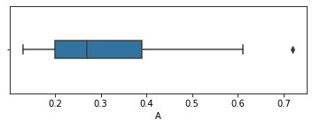

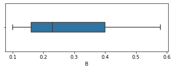

```python
# CHecking the normality assumition graphically through boxplot
plt.subplot(2,1,1)
sns.boxplot(df3['A'],width=0.2)
plt.show()
plt.subplot(2,1,2)
sns.boxplot(df3['B'],width=0.2)
plt.show()
```

We can view from the distribution of the box plot both variables seem to be skewed to the right as the right is much longer. we can also observe that the distance of Q3 is also further away from Q2 as compared to the distance between Q1 and Q2

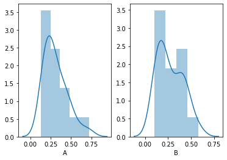

```python
# Checking the normality assumption graphically through distplot
plt.subplot(1,2,1)
sns.distplot(df3['A'])
plt.subplot(1,2,2)
sns.distplot(df3['B'])
plt.show()
```

Basis the distribution plot, we can see that the distribution is right skewed.

```python
#Checking the normality assumption statically through empirical rule
Mean_A=df3['A'].mean()
Std_A=df3['A'].std()
count_A=df3[(df3['A']>(Mean_A-Std_A)) & (df3['A'] < (Mean_A+Std_A))].count()
total_A=df3['A'].count()
pct_within_sd_A=(count_A/total_A)*100
pct_within_sd_A
```

```
A    67.741935
B    67.741935
dtype: float64
```

```python
Mean_B=df3['B'].mean()
Std_B=df3['B'].std()
count_B=df3[(df3['B']>(Mean_B-Std_B)) & (df3['B'] < (Mean_B+Std_B))].count()
total_B=df3['B'].count()
pct_within_sd_B=(count_B/total_B)*100
pct_within_sd_B
```

```
A    61.290323
B    61.290323
dtype: float64
```

For a normal distribution, we know that as the emprical rule states, 68% of the values in the data set will lie within 1 standard deviation of the mean. To check this assumption we have perofrmed the calculation and we can note that only 61% of the values fall between 1 standard deviation. Hence Shingles B does not follow normal distribution

## 3.8. Do you think that the assumption needed in order to conduct the hypothesis tests above is valid? Explain.

Yes the assumption that the population follows normal distribution is valid as we know that based on the central limit theorem - Given random and independent sample of N observations each, the distribution of sample mean approaches normality as the size of N increases. This means that when N increases the sample mean will follow normal distribution. In this case we are trying to hypothesize about the population mean. Here the population size N is unknown, however it would ideally be a large number due to which its distribution will be the normal distribution